# Plant Evolution

## The big picture: Plants evolved from green algae

- **Cyanobacteria & protist made landfall ~1.2 bya**
  - plants, and fungi ~500 mya
  - first forests 385 mya
- **Plants evolved from green algae**
  - algal ancestors made slow transition to land
  - Several *‘derived shared traits’* with plants
- **Plants support all life on earth**
  - oxygen to breath
  - food to eat
  - new habitats

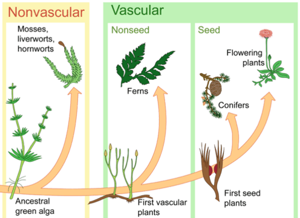

## Green Algae

- **Sister group to land plants**
  - marine and *freshwater*
  - single and *multi-cellular*
  - broad, thick filaments resembling plant structures
  - some have *Alternations of Generations*
  - evolved around ~750mya
- **Key reproductive features:**
  - *Oogonia* = egg containing cell
  - *Antheridium* = sperm containing cell

[figure not shown]

[figure not shown]

## Molecular evidence points at charophytes (freshwater)

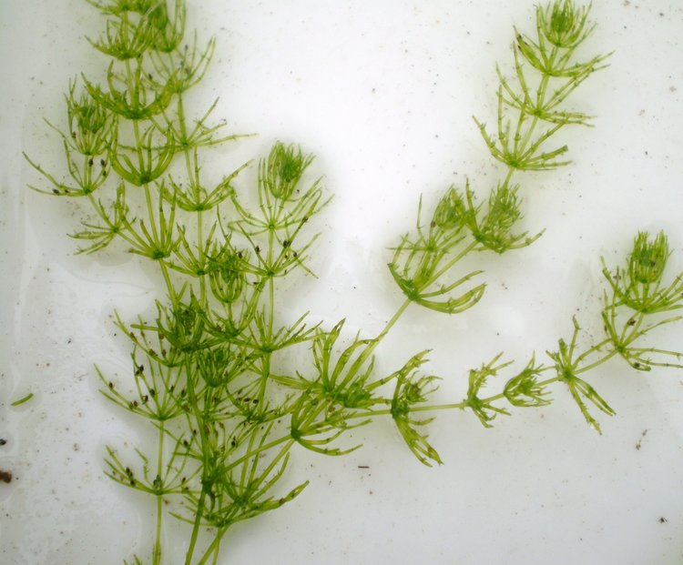

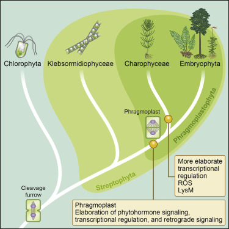

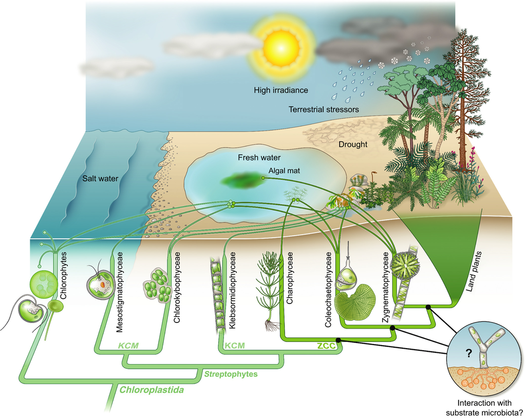

## Land plants are a monophyletic group

[figure not shown]

## All land plants are *Embryophytes*

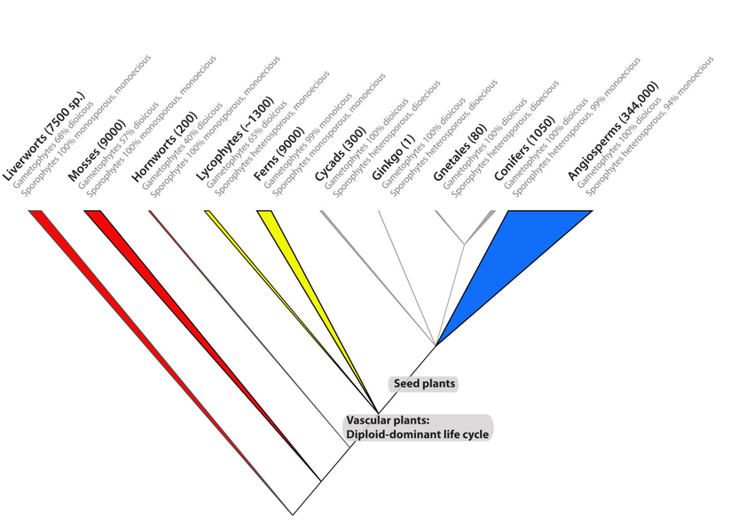

- **10 divisions of land plants**
  - does not include algae
  - divisions are species diverse
- **Zygote develops into multi-cell embryo**
  - enclosed in reproductive structure
  - algae do not retain embryo
- **Land plant & embryophyte terms used interchangeably**

## Shared traits define land plant evolution

[figure not shown]

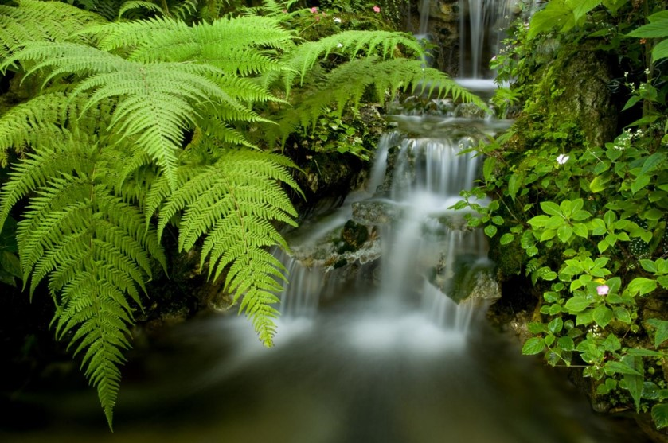

## Multi-cellular, Dependent embryos (placental transfer)

[figure not shown]

## Waxy cuticle and stomata

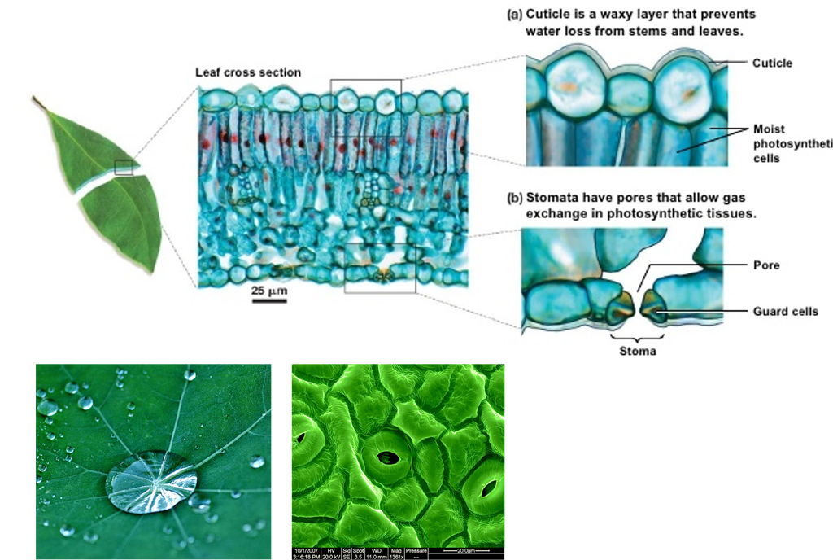

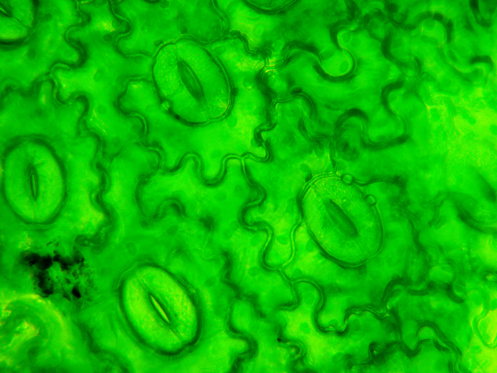

## Multi-cellular Gametangia

[figure not shown]

## Photosynthesis with unique pigments (chlorophyll A & B)

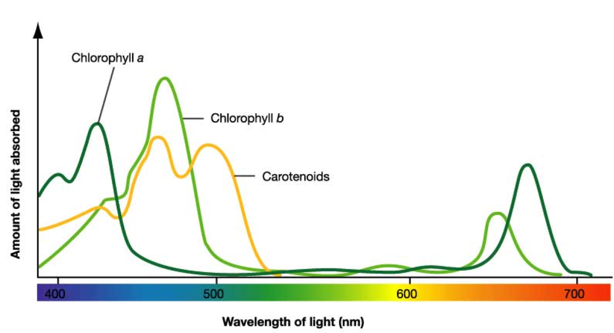

## Unique cell walls

- **Cells walls made of cellulose**
  - not unique to plants
- **Pectin to fortify cell walls**
  - unique to plants
- **Produce cells walls uniquely**
  - dividing wall at end of mitosis

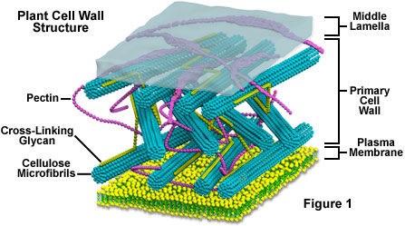

## Alternation of generations

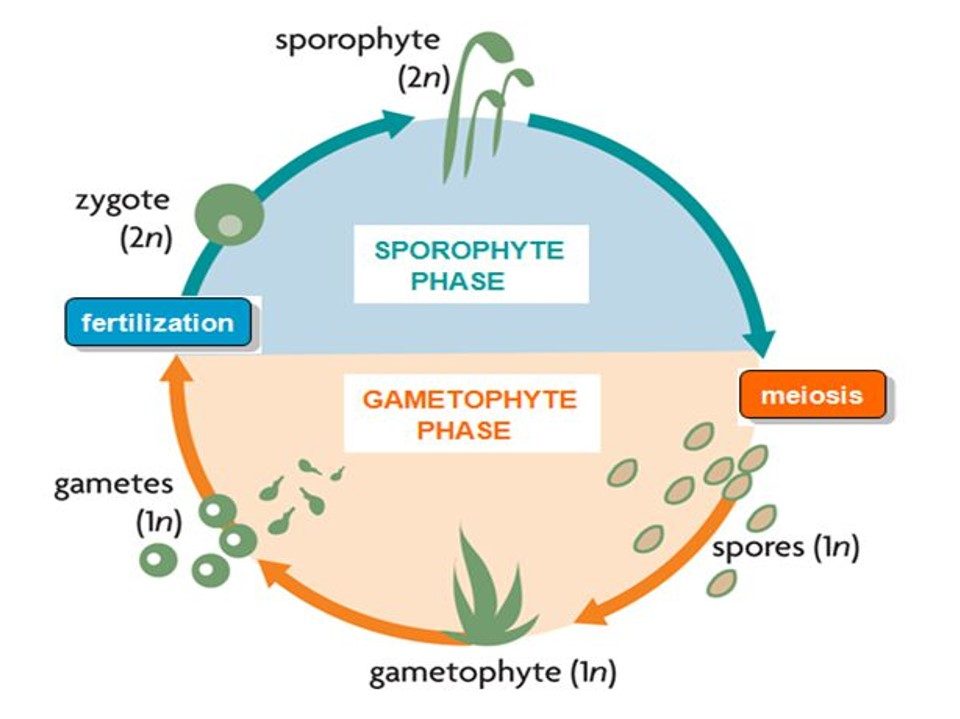

- **Land plants alternate between diplod (2N) and haploid (1N) generations**
  - diploid = *sporophyte*
  - haploid = *gametophyte*
- **sex cells (1N) make zygote (2N)**
- **zygote → embryo → sporophyte (all mitosis)**
- **sporophyte makes spores (1N) by meosis**
- **spores germinate into gametophyte (1N) by mitosis**
- **gametophyte makes sex cells (sperm and egg)**
- **Dominance of different generations key for evolution**

## First plant group: non-vascular bryophytes (mosses)

- **Mosses, hornworts and liverworts**
  - Fossils of bryophyte spores ~470mya
- **Non-vascular; ground hugging carpets**
  - bodies to thin to support height growth
- **Have a rhizoid but not a root**
  - anchors plant
  - does not uptake water
- **Need H<sub>2</sub>0 for swimming sperm**

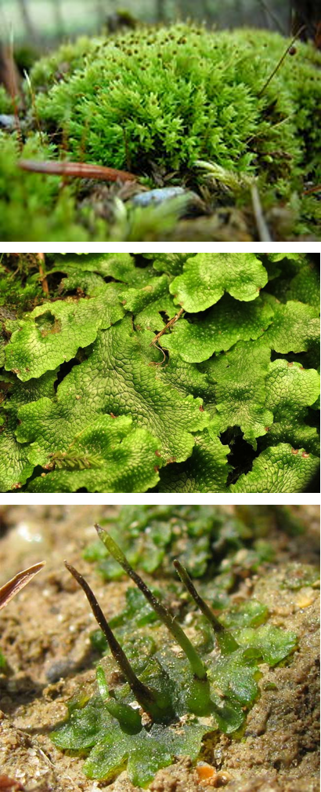

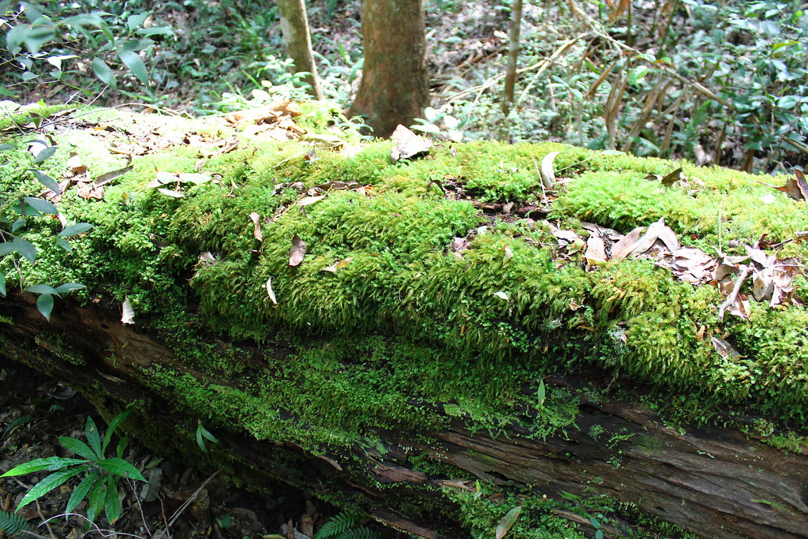

## Bryophytes have gametophyte dominated life cycle

[figure not shown]

## Vascular plants were the next evolutionary step

- **Vascular plants show up ~425mya**
  - gametophytes become reduced
- **Developed a vascular system**
  - grow taller = get light
  - *xylem* and *phloem cells*
- **Developed leaves & roots**
  - better access to resources
- **First vascular plants lacked seeds**
  - sperm still needed to swim
  - ferns and lycophytes

[figure not shown]

## Lycophytes: First vascular plants

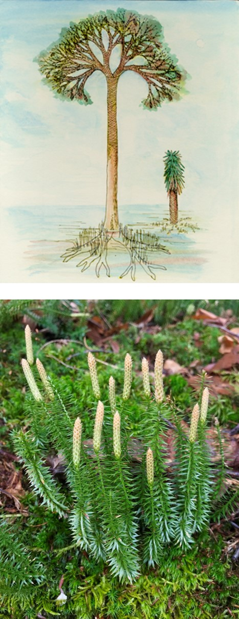

- **Independent, branched sporophyte**
  - now with roots
- **Lignified vascular tissue**
  - xylem and phloem
- **Leaves are microphylls**
  - one vein per leaf (unique trait)
- **Lycophyte forests once existed**
  - now gives us coal

## Ferns

- **Whisk Ferns, Equisetum & Ferns**
- **Leaves are megaphylls**
  - many veins per leaf
- **Dominant sporophyte**
- **Free-living gametophyte**
- **New *Gaga* genus with 19 species**
  - “We wanted to name this genus for Lady Gaga because of her fervent defense of equality and individual expression” Pryer @ Duke University

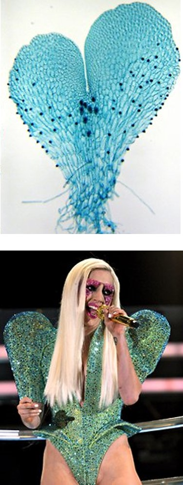

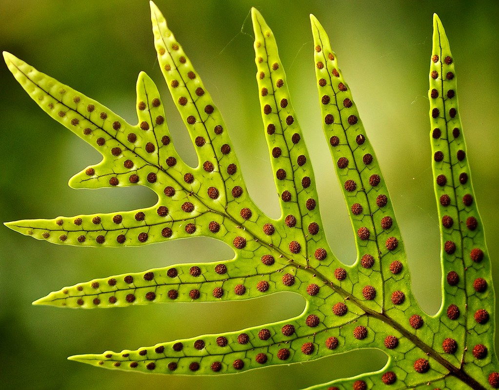

## Seedless vascular plants have free-living separate generations

- **Sporophyte: The fern you see in the woods**
  - becomes dominant stage
- **Gametophye: independent haploid generation**
  - start out female or bisexual
- **Derived Trait - compare to moss**
- **What does natural selection favor diploid dominant life cycles?**

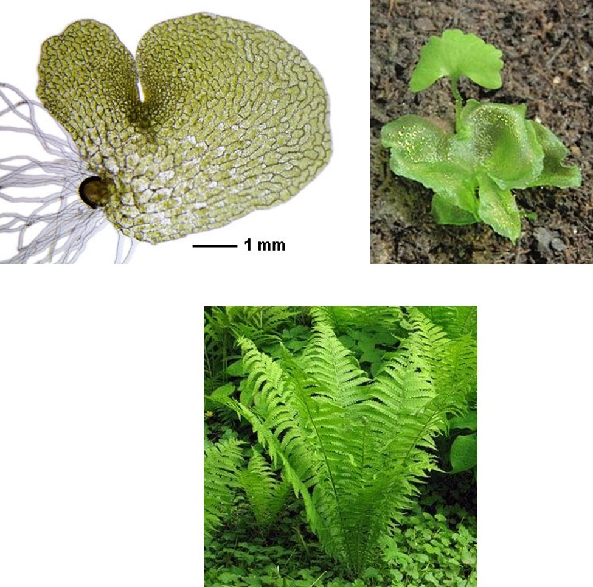

## Seed plants were the next evolutionary step

- **Seeds changed the course of plant evolution**
  - Seed plants show up ~360 mya when climate became drier
- **Seeds consists of embryo & nutrients**
  - surrounded by protective coat
- **Several other derived traits evolved:**
  - gametophytes reduced and protected
  - internal fertilization
  - sexed spores (heterospory)
- **2 living seed lineages**
  - gymnosperms (naked seed)
  - angiosperms (covered seed = fruits)

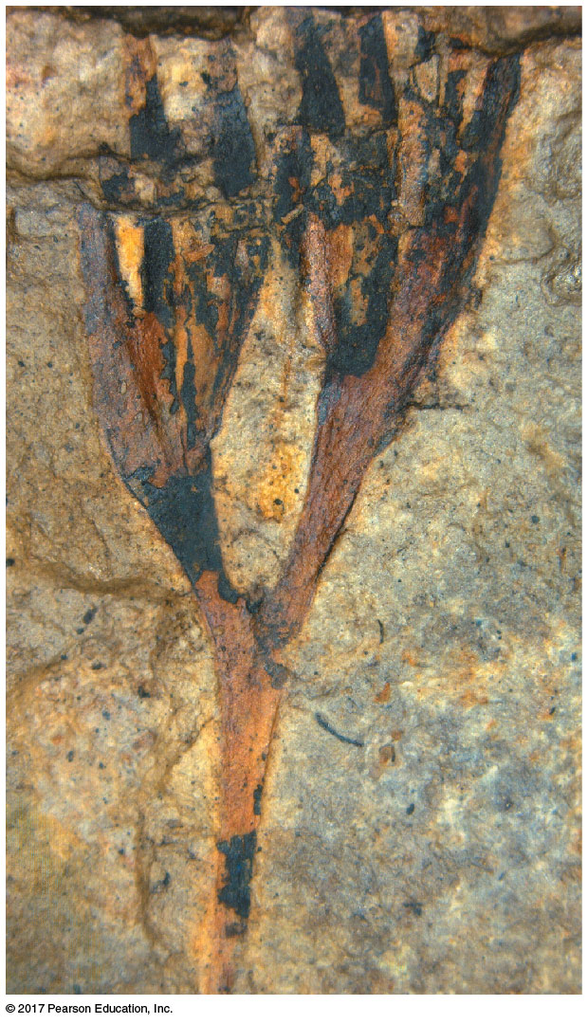

## Why seeds matter so much…

- **Before seeds, spore was only protective structure**
- **Seeds are multicellular**
  - lots of cells become food (endosperm)
- **Seeds can remain dormant for a long time**
  - seeds can be dispersed long distances
- **Gymnosperms: seeds exposed on sporophylls, form cones**
- **Angiosperms: seeds enclosed inside fruits**

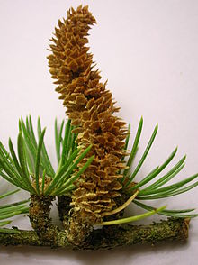

## 4 living lineages of gymnosperms

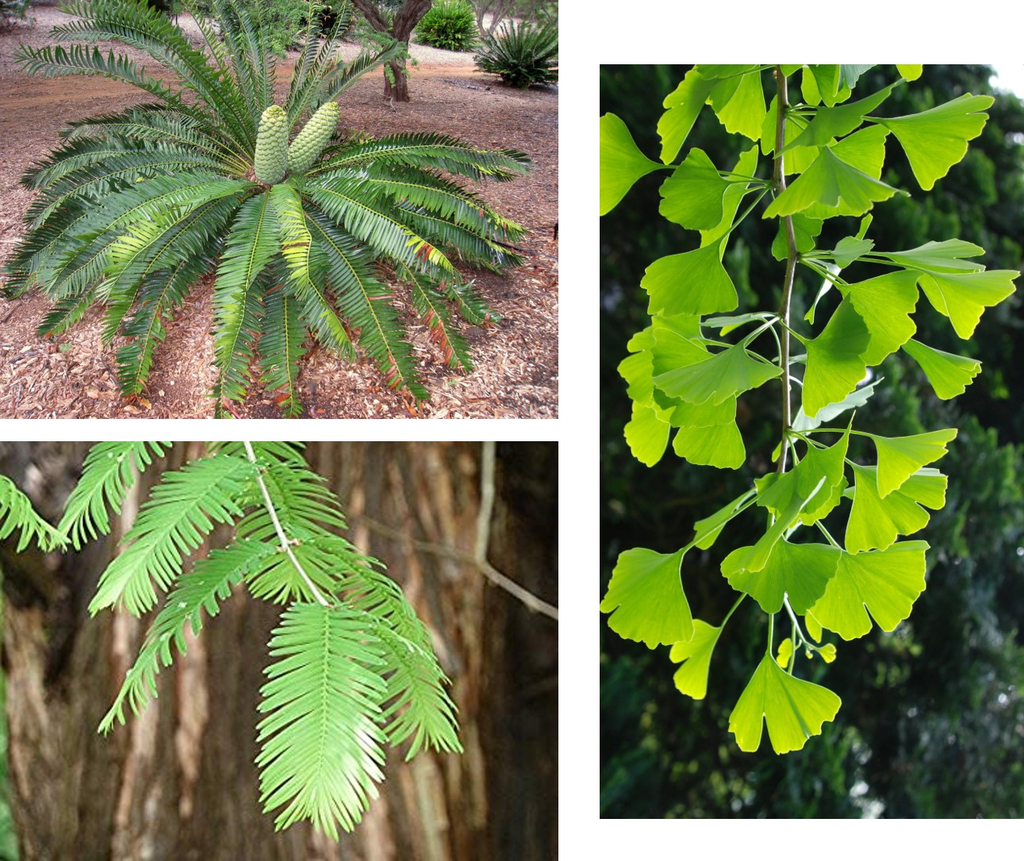

## Flowering plant diversity

[figure not shown]

## Angiosperm evolution: Flowers and animal pollinators

**Angiosperm and animal evolution have been intimately linked through coevolution, where the development of flowers and fruits provided a new food source for animals, which in turn helped pollinate the plants and disperse their seeds.**

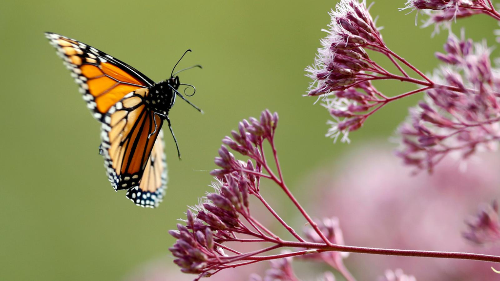

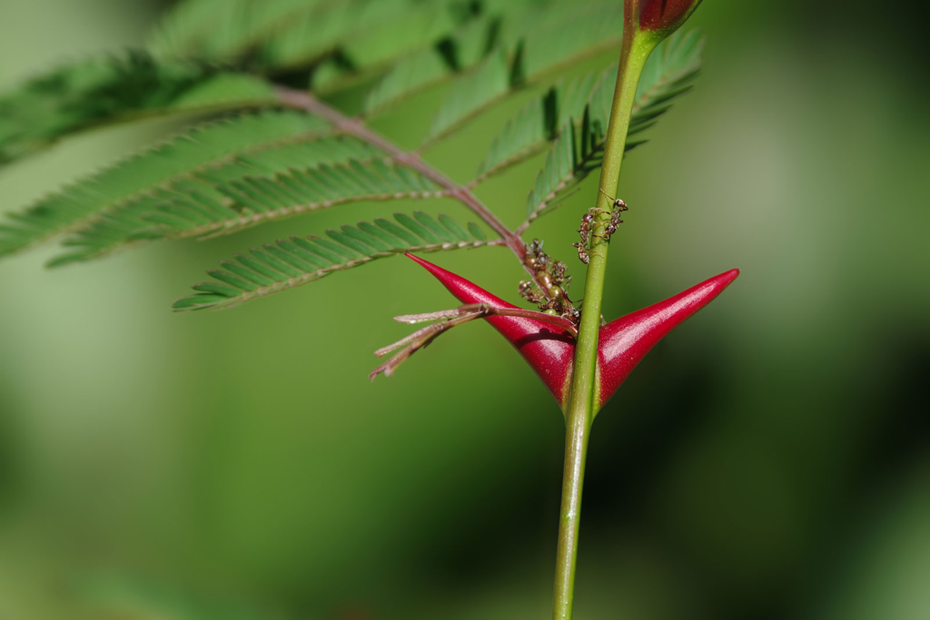